# Projeto Integrador Ciência de dados - IMIH

Gerson Vasconcelos Neto - Exercício 04

Março de 2018

# Introdução

Vamos estudar com uma amostra do banco de dados do Enade. O Enade, Exame Nacional de Desempenho dos Estudantes, é um dos procedimentos de avaliação do Sistema Nacional de Avaliação da Educação Superior (Sinaes). O teste avalia o rendimento dos alunos dos cursos de graduação, ingressantes e concluintes, em relação aos conteúdos programáticos dos cursos em que estão matriculados. O exame é obrigatório para os alunos selecionados e condição indispensável para a emissão do histórico escolar. Seus resultados poderão produzir dados por instituição de educação superior, categoria administrativa, organização acadêmica, município, estado, região geográfica e Brasil. Assim, serão construídos referenciais que permitam a definição de ações voltadas à melhoria da qualidade dos cursos de graduação por parte de professores, técnicos, dirigentes e autoridades educacionais.

## Exercícios com uma amostra do ENADE:

**1. Extraia a média, a mediana, mínimo, máximo, variância e desvio padrão da idade para todos os alunos da nossa amostra aleatória.**

```r
summary(enade14$nu_idade) # média, mediana, min e máx
```

```
   Min. 1st Qu.  Median    Mean 3rd Qu.    Max.
  18.00   23.00   27.00   29.89   34.00   73.00
```

```r
var(enade14$nu_idade) # Variância
```

```
[1] 72.35032
```

```r
sd(enade14$nu_idade) # Desvio padrão
```

```
[1] 8.505899
```

**2. Elabore uma tabela de frequência da quantidade de alunos por sexo. Corrija a variável caso alguma categoria esteja “sobrando”.**

```
enade14$tp_sexo_l
      Frequência Percentual Perc. Válido
F           5744      57.44        57.45
M           4254      42.54        42.55
NA's           2       0.02
Total      10000     100.00       100.00
```

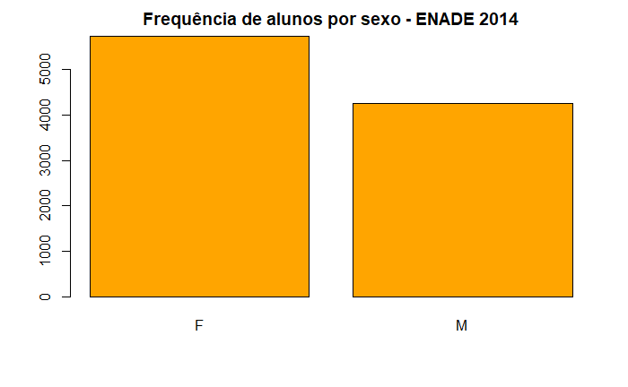

```r
library("descr")
enade14$tp_sexo_l <- enade14$tp_sexo
enade14$tp_sexo_l[enade14$tp_sexo_l == "N"] <- NA  # limpando a variável sexo em uma nova variável
freq(enade14$tp_sexo_l,
     col = "orange",
     main = "Frequência de alunos por sexo - ENADE 2014")
```

**3. Agora extraia a média, a mediana, mínimo, máximo, variância e desvio padrão da idade para cada categoria de sexo. Exiba os mesmos resultados com um gráfico.**

```r
enade14$tp_masc <- ifelse(enade14$tp_sexo_l == "M", 1, 0) #criando a dummy masculina
summary(enade14$nu_idade[enade14$tp_masc == 1]) # para os homens
```

```
   Min. 1st Qu.  Median    Mean 3rd Qu.    Max.    NA's
  18.00   23.00   27.00   28.97   32.00   73.00       2
```

```r
var(enade14$nu_idade[enade14$tp_masc == 1], na.rm = T)
```

```
[1] 60.61172
```

```r
sd(enade14$nu_idade[enade14$tp_masc == 1], na.rm = T)
```

```
[1] 7.785353
```

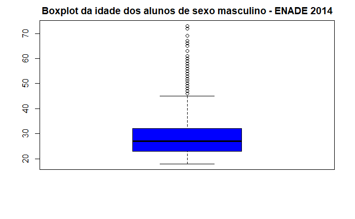

```r
boxplot(enade14$nu_idade[enade14$tp_masc == 1],
        col = "blue",
        main = "Boxplot da idade dos alunos de sexo masculino - ENADE 2014")
```

```r
summary(enade14$nu_idade[enade14$tp_masc == 0]) # para as mulheres
```

```
   Min. 1st Qu.  Median    Mean 3rd Qu.    Max.    NA's
  18.00   23.00   28.00   30.57   36.00   72.00       2
```

```r
var(enade14$nu_idade[enade14$tp_masc == 0], na.rm = T)
```

```
[1] 79.85742
```

```r
sd(enade14$nu_idade[enade14$tp_masc == 0], na.rm = T)
```

```
[1] 8.936298
```

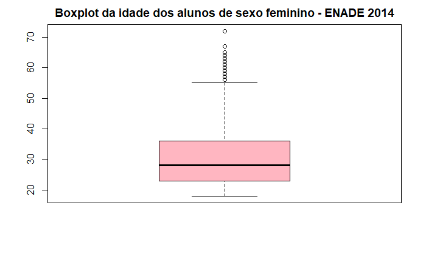

```r
boxplot(enade14$nu_idade[enade14$tp_masc == 0],
        col = "lightpink",
        main = "Boxplot da idade dos alunos de sexo feminino - ENADE 2014")
```

**4. Agora extraia a média, a mediana, mínimo, máximo, variância e desvio padrão da idade para cada categoria de cor/raça. Exiba os mesmos resultados com um gráfico.**

```r
summary(enade14$nu_idade[enade14$qe_i2 == "a"]) # para brancos
```

```
   Min. 1st Qu.  Median    Mean 3rd Qu.    Max.    NA's
  18.00   23.00   26.00   29.11   33.00   72.00    1306
```

```r
var(enade14$nu_idade[enade14$qe_i2 == "a"], na.rm = T)
```

```
[1] 70.21313
```

```r
sd(enade14$nu_idade[enade14$qe_i2 == "a"], na.rm = T)
```

```
[1] 8.379328
```

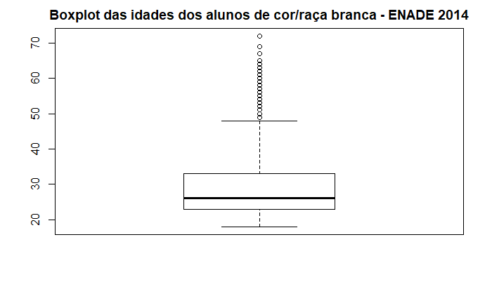

```r
boxplot(enade14$nu_idade[enade14$qe_i2 == "a"],
        col = "white",
        main = "Boxplot das idades dos alunos de cor/raça branca - ENADE 2014")
```

```r
summary(enade14$nu_idade[enade14$qe_i2 == "b"]) # para negros
```

```
   Min. 1st Qu.  Median    Mean 3rd Qu.    Max.    NA's
   19.0    24.0    28.0    30.9    36.0    73.0    1306
```

```r
var(enade14$nu_idade[enade14$qe_i2 == "b"], na.rm = T)
```

```
[1] 82.98265
```

```r
sd(enade14$nu_idade[enade14$qe_i2 == "b"], na.rm = T)
```

```
[1] 9.109481
```

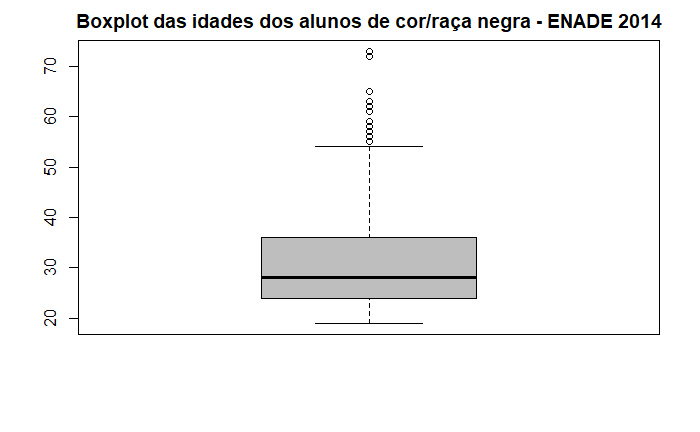

```r
boxplot(enade14$nu_idade[enade14$qe_i2 == "b"],
        col = "grey",
        main = "Boxplot das idades dos alunos de cor/raça negra - ENADE 2014")
```

```r
summary(enade14$nu_idade[enade14$qe_i2 == "c"]) # para pardos/mulatos
```

```
   Min. 1st Qu.  Median    Mean 3rd Qu.    Max.    NA's
  19.00   23.00   28.00   30.37   35.00   66.00    1306
```

```r
var(enade14$nu_idade[enade14$qe_i2 == "c"], na.rm = T)
```

```
[1] 70.85972
```

```r
sd(enade14$nu_idade[enade14$qe_i2 == "c"], na.rm = T)
```

```
[1] 8.417822
```

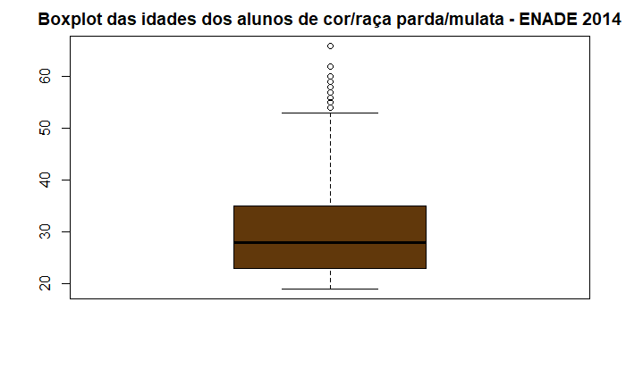

```r
boxplot(enade14$nu_idade[enade14$qe_i2 == "c"],
        col = "#61380B",
        main = "Boxplot das idades dos alunos de cor/raça parda/mulata - ENADE 2014")
```

```r
summary(enade14$nu_idade[enade14$qe_i2 == "d"]) # para amarelos/orientais
```

```
   Min. 1st Qu.  Median    Mean 3rd Qu.    Max.    NA's
  20.00   24.00   27.00   29.16   32.00   53.00    1306
```

```r
var(enade14$nu_idade[enade14$qe_i2 == "d"], na.rm = T)
```

```
[1] 49.1164
```

```r
sd(enade14$nu_idade[enade14$qe_i2 == "d"], na.rm = T)
```

```
[1] 7.008309
```

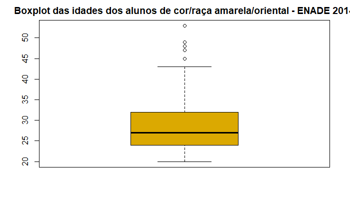

```r
boxplot(enade14$nu_idade[enade14$qe_i2 == "d"],
        col = "#DBA901",
        main = "Boxplot das idades dos alunos de cor/raça amarela/oriental - ENADE 2014")
```

```r
summary(enade14$nu_idade[enade14$qe_i2 == "e"]) # para indígenas
```

```
   Min. 1st Qu.  Median    Mean 3rd Qu.    Max.    NA's
  20.00   23.00   29.50   30.42   35.00   61.00    1306
```

```r
var(enade14$nu_idade[enade14$qe_i2 == "e"], na.rm = T)
```

```
[1] 73.54595
```

```r
sd(enade14$nu_idade[enade14$qe_i2 == "e"], na.rm = T)
```

```
[1] 8.575894
```

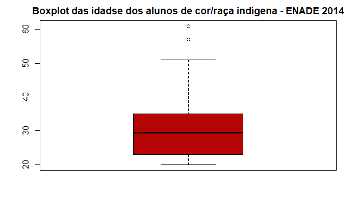

```r
boxplot(enade14$nu_idade[enade14$qe_i2 == "e"],
        col = "#B40404",
        main = "Boxplot das idadse dos alunos de cor/raça indígena - ENADE 2014")
```

ou, para um melhor visualização podemos plotar os gráficos juntos:

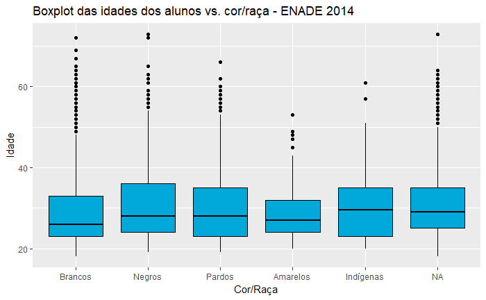

```r
library(ggplot2)
ggplot(data=enade14, aes(x=Raca, y=enade14$nu_idade))+
  geom_boxplot(fill = "#01A9DB", colour = "black")+
  labs(title = "Boxplot das idades dos alunos vs. cor/raça - ENADE 2014",
       x = "Cor/Raça",
       y = "Idade")
```

```r
## denovo não consgui remover os NA's. da aquela ajuda ae Neylson!
```

**5. Verifique a distribuição de alunos por região do país. Exiba uma tabela de frequências e um gráfico.**

```
regiao
             Frequência Percentual
Norte               770       7.70
Nordeste           1927      19.27
Sudeste            4451      44.51
Sul                1968      19.68
Centro-Oeste        884       8.84
Total             10000     100.00
```

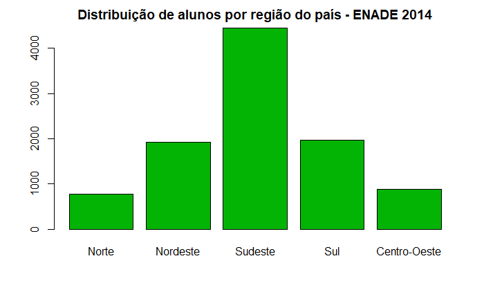

```r
regiao <- as.factor(enade14$co_regiao_curso)
levels(regiao) <- c("Norte", "Nordeste", "Sudeste", "Sul", "Centro-Oeste") # renomeando as variáveis
freq(regiao,
     col = "#04B404",
     main = "Distribuição de alunos por região do país - ENADE 2014")
```

**6. Vamos investigar a associação entre a renda e a cor. Faça uma tabela cruzada entre essas duas variáveis.**

```r
Renda <- as.factor(enade14$qe_i8) # renomeando as variáveis de renda
levels(Renda) <- c(" -| 1,5", "1,5 -| 3", "3 -| 4,5", "4,5 -| 6", "6 -| 10", "10 -| 30", "30 +")
Raca <- as.factor(enade14$qe_i2) # renomeando as variáveis de raça
levels(Raca) <- c("Brancos", "Negros", "Pardos", "Amarelos", "Indígenas")
renda_cor <- table(Raca, Renda)
renda_cor
```

```
           Renda
Raca         -| 1,5 1,5 -| 3 3 -| 4,5 4,5 -| 6 6 -| 10 10 -| 30 30 +
  Brancos       549     1141     1005      661     734      453   63
  Negros        231      309      172       86      69       25    1
  Pardos        760      933      553      285     311      132   14
  Amarelos       27       33       15       13      22       16    3
  Indígenas      28       29        8        4       3        5    1
```

```r
#enade14$cor_raca <- enade14$qe_i2  #mudando as labels de um outro modo
#enade14$cor_raca[enade14$cor_raca == "a"] <- "Branco"
#enade14$cor_raca[enade14$cor_raca == "b"] <- "Negro"
#enade14$cor_raca[enade14$cor_raca == "c"] <- "Pardo"
#enade14$cor_raca[enade14$cor_raca == "d"] <- "Amarelo"
#enade14$cor_raca[enade14$cor_raca == "e"] <- "Indígena"
#enade14$renda <- enade14$qe_i8
#enade14$renda[enade14$renda == "a"] <- " -| 1,5"
#enade14$renda[enade14$renda == "b"] <- "1,5 -| 3"
#enade14$renda[enade14$renda == "c"] <- "3 -| 4,5"
#enade14$renda[enade14$renda == "d"] <- "4,5 -| 6"
#enade14$renda[enade14$renda == "e"] <- "6 -| 10"
#enade14$renda[enade14$renda == "f"] <- "10 -| 30"
#enade14$renda[enade14$renda == "g"] <- "30 +"
```

## Desafios:

**1. Guarde a tabela que você programou no exercício 6 num objeto. Existe algum teste estatístico para sabermos se existe associação entre essas variáveis? Rode o teste e apresente os resultados. (nível easy)**

```r
xsq = chisq.test(renda_cor, correct = F)
```

[output not shown]

```r
xsq
```

```
    Pearson's Chi-squared test

data:  renda_cor
X-squared = 534.9, df = 24, p-value < 2.2e-16
```

**2. Comente os resultados (nível medium)**

Como testamos o nível de associação de variáveis categóricas, vamos usar o teste qui-quadrado. Nós vemos no resultado que o p-value é menor que o nível de significância 0,05 e que temos um alto valor para o qui-quadrado. Portanto, rejeitamos a hipóstese nula e concluimos que a renda e a cor/raça têm uma associação significante.

**3. Verifique a variável categoria administrativa da IES no dicionário de variáveis. Recategorize a variável em uma binária: “Pública e Privada”. Crie uma nova variável para armezenar esses dados. (nível hard)**

```r
enade14$ies_pub <- ifelse(enade14$co_catad == 93 |
                     enade14$co_catad == 116 |
                     enade14$co_catad == 10001 |
                     enade14$co_catad == 10002 |
                     enade14$co_catad == 10003, 1, 0)
```

**4. Você consegue descobrir qual foi a média da nota geral dos alunos de pedagogia do Izabela Hendrix no Enade 2014? (nível Chuck Norris)**

```r
nt_iza <- enade14$nt_ger[enade14$co_ies == 216] # subsetting da IMIH
nt_iza_ped <- nt_iza[enade14$co_grupo == 2001] # subsetting de pedagogia da IMIH
mean(nt_iza_ped, na.rm = T)
```

```
[1] 402.2
```

```r
## mais fácil que empurrar bebo na ladeira! heheheh!
```